# Práctica 3 – GLMs en Pricing (R)

Administración Actuarial del Riesgo · Facultad de Ciencias, UNAM

Curso AAR 2026-2

27 de April de 2026

# 1 Introducción

**Objetivo:** Simular una cartera (autos como ejemplo), explorar los datos, ajustar modelos GLM de **frecuencia** y **severidad**, calcular la **prima pura** por póliza y evaluar la segmentación (**Gini**) y la interpretabilidad (**predicciones parciales**).

En este cuaderno aprenderás a modelar la frecuencia y severidad de siniestros para un portafolio de autos usando Modelos Lineales Generalizados (GLMs) en **R**.

> **Notas:**
> - Los comentarios y conclusiones incluyen fórmulas para justificar las decisiones de modelado. Las referencias teóricas se basan en datos de seguros reales.
> - Deberán usar las variables que encontraron en SESA de la práctica 1.

## 1.1 Paquetes requeridos

```r
# Paquetes para manipulación, modelado y visualización
library(dplyr)        # manipulación de datos
library(tidyr)        # reorganización
library(ggplot2)      # gráficos
library(MASS)         # glm.nb (binomial negativa) y fitdistr (Weibull)
library(broom)        # tidy() para tablas de coeficientes
library(knitr)        # kable para tablas
```

# 2 Paso 0 – Simulación de una cartera

## 2.1 Seguro de Autos

Supondremos que cada póliza tiene una **exposición** (en años), características del conductor y del vehículo, y un número de siniestros y monto de reclamaciones generado a partir de distribuciones paramétricas.

1. **Características de riesgo:** simularemos la edad del conductor (`DrivAge`), la antigüedad del vehículo (`VehAge`), la potencia (`VehPower`) y el tipo de área (`Area`).
2. **Frecuencia:** supondremos que el número de siniestros $N$ sigue una distribución Poisson con media

$$\lambda_i = \exp(\beta_0 + \beta_1 \, \text{Age}_i + \beta_2 \,
\text{VehAge}_i + \beta_3 \, \text{Area}_i) \times \text{Exposure}_i$$

## 2.2 Simulación

El siguiente código crea un `data.frame` simulando 10,000 pólizas conforme a estas hipótesis. Fijamos la semilla con `set.seed(42)` para que la simulación sea reproducible.

```r
# Semilla fija para reproducibilidad
set.seed(42)

# Número de pólizas a simular
n <- 10000
```

Simulamos la **exposición** de cada póliza (fracción del año durante la cual la póliza está vigente, entre 0.5 y 1.0) y se simulan características aleatorias de las pólizas.

```r
# Exposición (entre 0.5 y 1 año)
Exposure <- runif(n, min = 0.5, max = 1.0)

# Variables de riesgo
DrivAge  <- sample(18:74, size = n, replace = TRUE)
VehAge   <- sample(0:19,  size = n, replace = TRUE)
VehPower <- sample(4:12,  size = n, replace = TRUE)   # categorías 4–12
Area     <- sample(c("A","B","C","D","E","F"),
                   size = n, replace = TRUE,
                   prob = c(0.20, 0.20, 0.20, 0.15, 0.15, 0.10))
```

### 2.2.1 Coeficientes y simulación de la frecuencia

- **Coeficientes del modelo de frecuencia:** asignamos valores arbitrarios (`beta0`, `beta_age`, `beta_veh`, `beta_area`) que controlan la relación entre cada variable y el logaritmo de la tasa de siniestros.
- **Tasa de siniestros (`mu_freq`):** calculamos el predictor lineal `eta` y lo transformamos con `exp(eta)` para obtener un valor positivo. Multiplicamos por la exposición para obtener el número esperado de siniestros por póliza.
- **Número de siniestros:** `rpois(n, lambda = mu_freq)` genera conteos siguiendo Poisson.

```r
# Coeficientes para el modelo Poisson de frecuencia
beta0     <- -3.0
beta_age  <-  0.015   # incremento por cada año del conductor
beta_veh  <- -0.02    # vehículos viejos tienen menos siniestros
beta_area <- c(A = 0.0, B = 0.1, C = 0.2, D = 0.3, E = 0.4, F = 0.5)

# Predictor lineal y tasa de siniestros
eta     <- beta0 + beta_age * DrivAge + beta_veh * VehAge + beta_area[Area]
lam     <- exp(eta)
mu_freq <- lam * Exposure

# Número de siniestros por póliza
N <- rpois(n, lambda = mu_freq)

cat(sprintf("Frecuencia media teórica:  %.4f siniestros por póliza\n", mean(mu_freq)))
```

```
## Frecuencia media teórica:  0.0800 siniestros por póliza
```

```r
cat(sprintf("Frecuencia media simulada: %.4f siniestros por póliza\n", mean(N)))
```

```
## Frecuencia media simulada: 0.0795 siniestros por póliza
```

Estos parámetros determinan la relación logarítmica entre las covariables y la tasa de siniestros:
$$\lambda_i = \exp(\beta_i)\, \text{Exposure}_i$$

Por ejemplo, `beta_age = 0.015` implica un aumento relativo de $e^{0.015} \approx 1.015$ veces la frecuencia por cada año adicional del conductor.

### 2.2.2 Simulación de la severidad

Para las pólizas con al menos un siniestro ($N > 0$):

$$Y_{ij}\mid N_i>0 \sim \text{Gamma}(\mu_i,\phi),\quad \log\mu_i =
\alpha_0 + \alpha_1\,\text{VehPower}_i + \sum_k
\alpha_k^{(Area)}\,\mathbf{1}\{Area=k\}$$

```r
# Coeficientes del modelo de severidad
alpha0     <- 8.0
a_power    <- 0.03
alpha_area <- c(A = 0.00, B = 0.02, C = 0.06, D = 0.08, E = 0.12, F = 0.15)
phi        <- 1.5  # parámetro de dispersión Gamma (forma ~ 1/phi)

# Media de severidad por póliza
sev_mu <- exp(alpha0 + a_power * VehPower + alpha_area[Area])

# Generar severidades por póliza: suma de los N siniestros
claim_amount <- numeric(n)
for (i in seq_len(n)) {
  if (N[i] > 0) {
    # En R: rgamma(n, shape, scale)
    y <- rgamma(N[i], shape = 1 / phi, scale = sev_mu[i] * phi)
    claim_amount[i] <- sum(y)
  }
}

cat(sprintf("Severidad media teórica:  %.2f unidades monetarias\n", mean(sev_mu)))
```

```
## Severidad media teórica:  4045.98 unidades monetarias
```

```r
cat(sprintf("Severidad media simulada: %.2f unidades monetarias\n",
            mean(claim_amount[N > 0])))
```

```
## Severidad media simulada: 4250.93 unidades monetarias
```

Este paso te permite experimentar con los parámetros y entender cómo influyen en la frecuencia y severidad. Cuando utilices una cartera real, sustituye esta simulación por la carga de tus propios datos (por ejemplo, con `read.csv`).

### 2.2.3 Construcción del DataFrame

Construimos un `data.frame` con todas las variables simuladas: identificador de póliza, exposición, variables de riesgo, número de siniestros y montos de reclamación.

```r
df <- data.frame(
  IDpol       = seq_len(n),
  Exposure    = Exposure,
  DrivAge     = DrivAge,
  VehAge      = VehAge,
  VehPower    = factor(VehPower, levels = 4:12),  # categórica
  Area        = factor(Area, levels = c("A","B","C","D","E","F")),  # con orden
  ClaimNb     = N,
  ClaimAmount = claim_amount
)

head(df)
```

|  | IDpol | Exposure | DrivAge | VehAge | VehPower | Area | ClaimNb | ClaimAmount |
| --- | --- | --- | --- | --- | --- | --- | --- | --- |
| 1 | 1 | 0.9574030 | 22 | 7 | 10 | C | 0 | 0 |
| 2 | 2 | 0.9685377 | 22 | 15 | 11 | E | 0 | 0 |
| 3 | 3 | 0.6430698 | 21 | 18 | 12 | E | 0 | 0 |
| 4 | 4 | 0.9152238 | 59 | 10 | 9 | A | 0 | 0 |
| 5 | 5 | 0.8208728 | 25 | 16 | 4 | A | 0 | 0 |
| 6 | 6 | 0.7595480 | 29 | 0 | 8 | A | 0 | 0 |

# 3 Paso 1 – Análisis exploratorio (EDA)

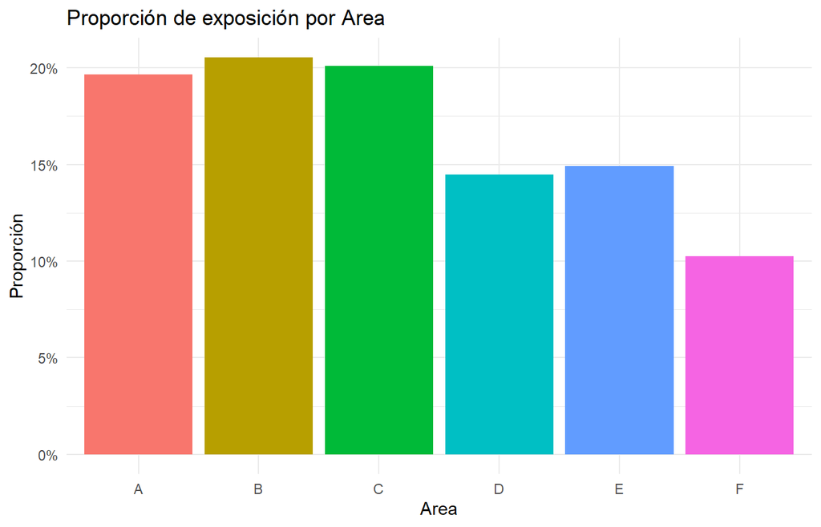

```r
# Proporción de exposición por Area
expo_by_area <- df %>%
  group_by(Area) %>%
  summarise(Expo = sum(Exposure), .groups = "drop") %>%
  mutate(Prop = Expo / sum(Expo))

ggplot(expo_by_area, aes(x = Area, y = Prop, fill = Area)) +
  geom_col() +
  scale_y_continuous(labels = scales::percent_format()) +
  labs(title = "Proporción de exposición por Area",
       x = "Area", y = "Proporción") +
  theme_minimal() +
  theme(legend.position = "none")
```

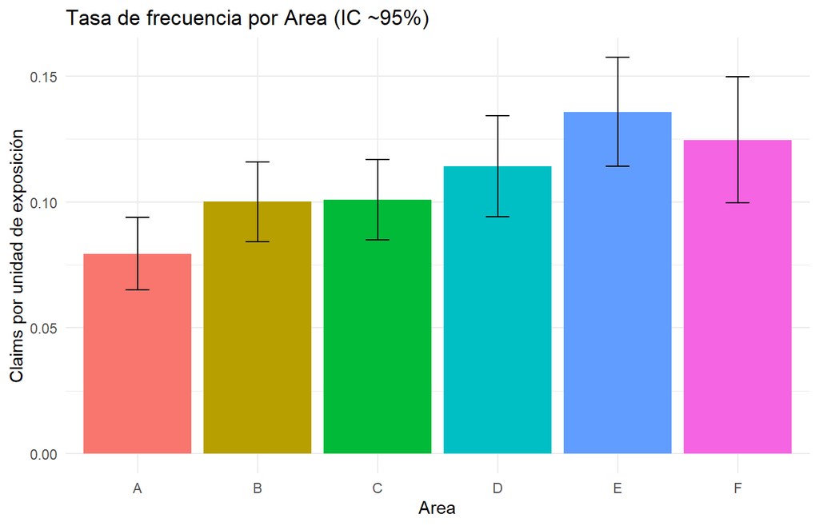

```r
# Tasa de frecuencia por Area con IC aproximado
g_area <- df %>%
  group_by(Area) %>%
  summarise(Claims = sum(ClaimNb),
            Expo   = sum(Exposure), .groups = "drop") %>%
  mutate(rate = Claims / Expo,
         se   = sqrt(rate / pmax(Expo, 1e-9)),
         lwr  = rate - 1.96 * se,
         upr  = rate + 1.96 * se)

ggplot(g_area, aes(x = Area, y = rate, fill = Area)) +
  geom_col() +
  geom_errorbar(aes(ymin = lwr, ymax = upr), width = 0.2) +
  labs(title = "Tasa de frecuencia por Area (IC ~95%)",
       x = "Area", y = "Claims por unidad de exposición") +
  theme_minimal() +
  theme(legend.position = "none")
```

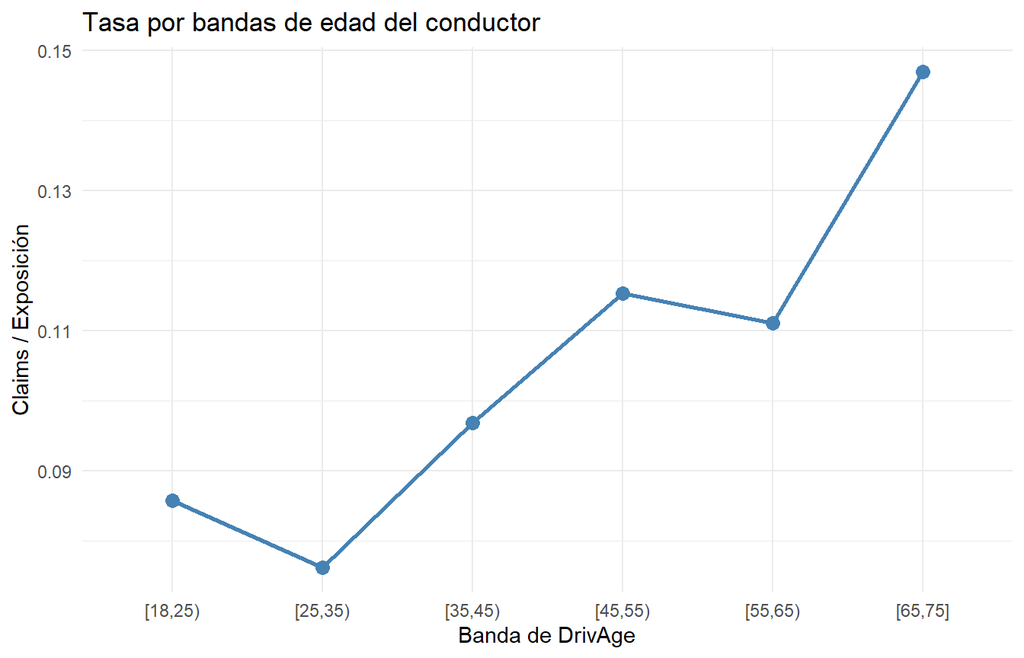

```r
# Bandas de DrivAge
df <- df %>%
  mutate(DrivAgeBand = cut(DrivAge,
                           breaks = c(18, 25, 35, 45, 55, 65, 75),
                           right = FALSE,
                           include.lowest = TRUE))

rate_age <- df %>%
  group_by(DrivAgeBand) %>%
  summarise(rate = sum(ClaimNb) / sum(Exposure), .groups = "drop")

ggplot(rate_age, aes(x = DrivAgeBand, y = rate, group = 1)) +
  geom_line(color = "steelblue", linewidth = 1) +
  geom_point(size = 3, color = "steelblue") +
  labs(title = "Tasa por bandas de edad del conductor",
       x = "Banda de DrivAge", y = "Claims / Exposición") +
  theme_minimal()
```

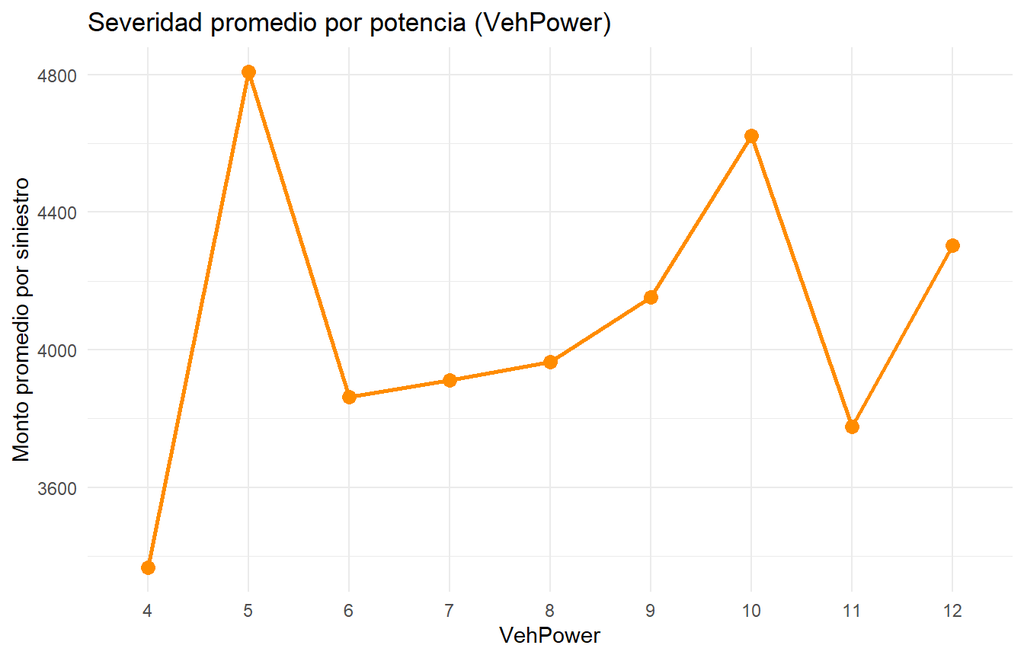

```r
# Severidad promedio por VehPower (solo pólizas con siniestro)
sev_pw <- df %>%
  filter(ClaimNb > 0) %>%
  group_by(VehPower) %>%
  summarise(SevProm = sum(ClaimAmount) / sum(ClaimNb), .groups = "drop")

ggplot(sev_pw, aes(x = VehPower, y = SevProm, group = 1)) +
  geom_line(color = "darkorange", linewidth = 1) +
  geom_point(size = 3, color = "darkorange") +
  labs(title = "Severidad promedio por potencia (VehPower)",
       x = "VehPower", y = "Monto promedio por siniestro") +
  theme_minimal()
```

# 4 Paso 2 – Modelado de la frecuencia

La **frecuencia** se define como el número de siniestros por unidad de exposición:

$$\text{Frequency}_i = \frac{\text{ClaimNb}_i}{\text{Exposure}_i}$$

## 4.1 Modelo Poisson con offset

Ajustamos un **GLM Poisson** con enlace log. Incluimos `log(Exposure)` como **offset** para tener en cuenta la exposición de cada póliza:

$$N_i \sim \text{Poisson}(\mu_i),\quad \log \mu_i =
\log(\text{Exposure}_i) + X_i\beta$$

En R, la categoría de referencia para un `factor` se controla con el orden de los niveles (el primer nivel es la referencia, en este caso `"A"` para `Area`). La variable `VehPower` es categórica con referencia `"4"`.

```r
formula_freq <- ClaimNb ~ DrivAge + VehAge + Area

model_pois <- glm(formula_freq,
                  data   = df,
                  family = poisson(link = "log"),
                  offset = log(Exposure))

summary(model_pois)
```

```
##
## Call:
## glm(formula = formula_freq, family = poisson(link = "log"), data = df,
##     offset = log(Exposure))
##
## Coefficients:
##              Estimate Std. Error z value Pr(>|z|)
## (Intercept) -2.908488   0.151952 -19.141  < 2e-16 ***
## DrivAge      0.013318   0.002194   6.070 1.28e-09 ***
## VehAge      -0.029414   0.006194  -4.748 2.05e-06 ***
## AreaB        0.233099   0.122654   1.900 0.057374 .
## AreaC        0.258478   0.123021   2.101 0.035634 *
## AreaD        0.361910   0.128906   2.808 0.004992 **
## AreaE        0.544087   0.122999   4.424 9.71e-06 ***
## AreaF        0.461701   0.137717   3.353 0.000801 ***
## ---
## Signif. codes:  0 '***' 0.001 '**' 0.01 '*' 0.05 '.' 0.1 ' ' 1
##
## (Dispersion parameter for poisson family taken to be 1)
##
##     Null deviance: 4085.1  on 9999  degrees of freedom
## Residual deviance: 4000.7  on 9992  degrees of freedom
## AIC: 5558.2
##
## Number of Fisher Scoring iterations: 6
```

Este modelo estima los parámetros $\beta$ de la ecuación:

$$\log(\mathbb{E}[\text{ClaimNb}_i]) = \log(\text{Exposure}_i) + \beta_0 +
\beta_1\,\text{DrivAge}_i + \beta_2\,\text{VehAge}_i +
\beta_3\,\text{Area}_i$$

Los coeficientes estimados se pueden comparar con los valores utilizados en la simulación para validar el modelo. Recordemos que $e^{\beta_j}$ es el **multiplicador** de tasa frente a la categoría de referencia.

```r
broom::tidy(model_pois) %>%
  mutate(exp_coef = exp(estimate)) %>%
  kable(digits = 4, caption = "Coeficientes del GLM Poisson y multiplicadores")
```

Coeficientes del GLM Poisson y multiplicadores

| term | estimate | std.error | statistic | p.value | exp_coef |
| --- | --- | --- | --- | --- | --- |
| (Intercept) | -2.9085 | 0.1520 | -19.1408 | 0.0000 | 0.0546 |
| DrivAge | 0.0133 | 0.0022 | 6.0698 | 0.0000 | 1.0134 |
| VehAge | -0.0294 | 0.0062 | -4.7484 | 0.0000 | 0.9710 |
| AreaB | 0.2331 | 0.1227 | 1.9005 | 0.0574 | 1.2625 |
| AreaC | 0.2585 | 0.1230 | 2.1011 | 0.0356 | 1.2950 |
| AreaD | 0.3619 | 0.1289 | 2.8075 | 0.0050 | 1.4361 |
| AreaE | 0.5441 | 0.1230 | 4.4235 | 0.0000 | 1.7230 |
| AreaF | 0.4617 | 0.1377 | 3.3525 | 0.0008 | 1.5868 |

## 4.2 Diagnóstico de sobredispersión

Calculamos las **medidas de sobredispersión**: la relación varianza/media de la frecuencia y la relación deviance/df. Si el cociente está cerca de 1, el supuesto Poisson es razonable.

```r
freq <- df$ClaimNb / df$Exposure
var_mean_ratio <- var(freq) / mean(freq)

deviance_df <- model_pois$deviance / model_pois$df.residual

cat(sprintf("Varianza/Media: %.2f\n", var_mean_ratio))
```

```
## Varianza/Media: 1.39
```

```r
cat(sprintf("Deviance/df:    %.2f\n", deviance_df))
```

```
## Deviance/df:    0.40
```

## 4.3 Modelo Binomial Negativa

Como alternativa, ajustamos un GLM **Binomial Negativa** (que admite sobredispersión):

```r
model_nb <- MASS::glm.nb(
  ClaimNb ~ DrivAge + VehAge + Area + offset(log(Exposure)),
  data = df
)

summary(model_nb)
```

```
##
## Call:
## MASS::glm.nb(formula = ClaimNb ~ DrivAge + VehAge + Area + offset(log(Exposure)),
##     data = df, init.theta = 476.5345622, link = log)
##
## Coefficients:
##              Estimate Std. Error z value Pr(>|z|)
## (Intercept) -2.908479   0.151965 -19.139  < 2e-16 ***
## DrivAge      0.013317   0.002194   6.069 1.29e-09 ***
## VehAge      -0.029414   0.006195  -4.748 2.05e-06 ***
## AreaB        0.233102   0.122664   1.900 0.057390 .
## AreaC        0.258481   0.123031   2.101 0.035645 *
## AreaD        0.361924   0.128917   2.807 0.004994 **
## AreaE        0.544098   0.123011   4.423 9.73e-06 ***
## AreaF        0.461688   0.137730   3.352 0.000802 ***
## ---
## Signif. codes:  0 '***' 0.001 '**' 0.01 '*' 0.05 '.' 0.1 ' ' 1
##
## (Dispersion parameter for Negative Binomial(476.5346) family taken to be 1)
##
##     Null deviance: 4083.4  on 9999  degrees of freedom
## Residual deviance: 3999.1  on 9992  degrees of freedom
## AIC: 5560.2
##
## Number of Fisher Scoring iterations: 1
##
##
##               Theta:  477
##           Std. Err.:  3005
## Warning while fitting theta: iteration limit reached
##
##  2 x log-likelihood:  -5542.219
```

## 4.4 Comparación AIC

```r
cat("AIC Poisson vs NB:\n")
```

```
## AIC Poisson vs NB:
```

```r
cat(sprintf("  Poisson: %.4f\n", AIC(model_pois)))
```

```
##   Poisson: 5558.2121
```

```r
cat(sprintf("  NB:      %.4f\n", AIC(model_nb)))
```

```
##   NB:      5560.2193
```

El modelo con AIC más bajo se considera preferible; en la simulación es probable que el Poisson tenga un AIC ligeramente menor debido a la forma en que se generaron los datos. **Adecuación del modelo de frecuencia:** el modelo Poisson es apropiado cuando la varianza es similar a la media; si la sobredispersión fuera fuerte, la Binomial Negativa se justifica.

# 5 Paso 3 – Modelado de la severidad

La **severidad** corresponde al monto promedio por siniestro:

$$\text{Severity}_i = \frac{\text{ClaimAmount}_i}{\max\{\text{ClaimNb}_i,
1\}}$$

Según la teoría actuarial, la severidad suele seguir una distribución **Gamma** con enlace log. Filtramos las pólizas con montos positivos y utilizamos el número de siniestros como peso para reflejar que una póliza con varios reclamos aporta más información.

```r
sev <- df %>%
  filter(ClaimAmount > 0) %>%
  mutate(Severity = ClaimAmount / ClaimNb)

head(sev)
```

|  | IDpol | Exposure | DrivAge | VehAge | VehPower | Area | ClaimNb | ClaimAmount | DrivAgeBand | Severity |
| --- | --- | --- | --- | --- | --- | --- | --- | --- | --- | --- |
| 1 | 24 | 0.9733341 | 30 | 16 | 10 | C | 1 | 5012.8828 | [25,35) | 5012.8828 |
| 2 | 29 | 0.7234848 | 24 | 3 | 12 | B | 1 | 3111.8628 | [18,25) | 3111.8628 |
| 3 | 39 | 0.9533007 | 68 | 10 | 11 | E | 1 | 2976.0216 | [65,75] | 2976.0216 |
| 4 | 62 | 0.9914086 | 51 | 2 | 7 | C | 2 | 11234.7588 | [45,55) | 5617.3794 |
| 5 | 87 | 0.6168517 | 48 | 1 | 6 | E | 1 | 571.3005 | [45,55) | 571.3005 |
| 6 | 89 | 0.5428060 | 73 | 14 | 5 | D | 1 | 1938.3472 | [65,75] | 1938.3472 |

La nueva tabla `sev` contiene únicamente las pólizas con siniestros y una columna `Severity` que representa el coste medio por siniestro.

## 5.1 Modelo Gamma completo

```r
formula_sev <- Severity ~ VehPower + VehAge + DrivAge + Area

model_gamma <- glm(formula_sev,
                   data    = sev,
                   family  = Gamma(link = "log"),
                   weights = ClaimNb)

summary(model_gamma)
```

```
##
## Call:
## glm(formula = formula_sev, family = Gamma(link = "log"), data = sev,
##     weights = ClaimNb)
##
## Coefficients:
##               Estimate Std. Error t value Pr(>|t|)
## (Intercept)  8.154e+00  2.024e-01  40.285   <2e-16 ***
## VehPower5    3.285e-01  1.704e-01   1.928   0.0542 .
## VehPower6    1.508e-01  1.667e-01   0.905   0.3658
## VehPower7    1.607e-01  1.666e-01   0.965   0.3350
## VehPower8    1.381e-01  1.756e-01   0.786   0.4321
## VehPower9    1.763e-01  1.726e-01   1.021   0.3074
## VehPower10   3.621e-01  1.791e-01   2.022   0.0435 *
## VehPower11   1.148e-01  1.765e-01   0.651   0.5154
## VehPower12   2.247e-01  1.823e-01   1.232   0.2183
## VehAge      -6.605e-03  7.349e-03  -0.899   0.3690
## DrivAge      7.739e-05  2.554e-03   0.030   0.9758
## AreaB       -1.160e-01  1.458e-01  -0.796   0.4265
## AreaC        4.195e-02  1.464e-01   0.287   0.7746
## AreaD        1.375e-01  1.533e-01   0.897   0.3700
## AreaE       -2.313e-02  1.464e-01  -0.158   0.8746
## AreaF        1.401e-01  1.633e-01   0.858   0.3912
## ---
## Signif. codes:  0 '***' 0.001 '**' 0.01 '*' 0.05 '.' 0.1 ' ' 1
##
## (Dispersion parameter for Gamma family taken to be 1.390439)
##
##     Null deviance: 1416.9  on 759  degrees of freedom
## Residual deviance: 1401.1  on 744  degrees of freedom
## AIC: 14754
##
## Number of Fisher Scoring iterations: 8
```

## 5.2 Tratamiento de siniestros grandes (recorte al percentil 95)

El modelo Gamma es sensible a los siniestros extremos; al recortar las reclamaciones por encima del percentil 95 se obtiene un modelo más robusto.

```r
threshold <- quantile(sev$ClaimAmount, probs = 0.95)
sev_trim  <- sev %>% filter(ClaimAmount <= threshold)

model_gamma_trim <- glm(formula_sev,
                        data    = sev_trim,
                        family  = Gamma(link = "log"),
                        weights = ClaimNb)

cat(sprintf("Umbral del 95%% para grandes siniestros: %.2f\n", threshold))
```

```
## Umbral del 95% para grandes siniestros: 15308.19
```

```r
summary(model_gamma_trim)
```

```
##
## Call:
## glm(formula = formula_sev, family = Gamma(link = "log"), data = sev_trim,
##     weights = ClaimNb)
##
## Coefficients:
##              Estimate Std. Error t value Pr(>|t|)
## (Intercept)  8.096984   0.186797  43.346   <2e-16 ***
## VehPower5    0.015057   0.157935   0.095    0.924
## VehPower6   -0.069161   0.152239  -0.454    0.650
## VehPower7    0.075859   0.151403   0.501    0.617
## VehPower8   -0.100712   0.162349  -0.620    0.535
## VehPower9   -0.001237   0.158167  -0.008    0.994
## VehPower10   0.226389   0.164548   1.376    0.169
## VehPower11  -0.144144   0.163226  -0.883    0.377
## VehPower12   0.198130   0.165730   1.196    0.232
## VehAge       0.002835   0.006788   0.418    0.676
## DrivAge      0.000638   0.002375   0.269    0.788
## AreaB       -0.218488   0.134980  -1.619    0.106
## AreaC       -0.066203   0.135990  -0.487    0.627
## AreaD       -0.031942   0.141883  -0.225    0.822
## AreaE       -0.062515   0.135214  -0.462    0.644
## AreaF       -0.024501   0.152223  -0.161    0.872
## ---
## Signif. codes:  0 '***' 0.001 '**' 0.01 '*' 0.05 '.' 0.1 ' ' 1
##
## (Dispersion parameter for Gamma family taken to be 1.124406)
##
##     Null deviance: 1229.9  on 721  degrees of freedom
## Residual deviance: 1216.6  on 706  degrees of freedom
## AIC: 13663
##
## Number of Fisher Scoring iterations: 9
```

## 5.3 Ajuste de una distribución Weibull

Como contraste con el modelo Gamma, ajustamos una **distribución Weibull** a la severidad usando `MASS::fitdistr`. La Weibull no incorpora covariables, por lo que la severidad predicha es constante para todas las pólizas.

```r
sev_values <- sev$Severity

fit_weib <- MASS::fitdistr(sev_values, densfun = "weibull")
shape_weib <- fit_weib$estimate["shape"]
scale_weib <- fit_weib$estimate["scale"]

cat(sprintf("Parámetros Weibull: shape = %.3f, scale = %.1f\n",
            shape_weib, scale_weib))
```

```
## Parámetros Weibull: shape = 0.776, scale = 3700.2
```

```r
# Media de la Weibull: scale * Gamma(1 + 1/shape)
weibull_mean <- scale_weib * gamma(1 + 1 / shape_weib)
cat(sprintf("Severidad media estimada (Weibull): %.4f\n", weibull_mean))
```

```
## Severidad media estimada (Weibull): 4288.9363
```

```r
# Predicción de severidad constante para cada póliza
sev_pred_weibull <- rep(weibull_mean, nrow(df))
```

El ajuste de la Weibull produce parámetros de forma y escala que resumen la distribución de la severidad simulada. La comparación entre la media Gamma y la media Weibull ayuda a evaluar la adecuación de las distribuciones.

## 5.4 Comparación AIC del Gamma completo y recortado

```r
cat(sprintf("AIC modelo completo:  %.4f\n", AIC(model_gamma)))
```

```
## AIC modelo completo:  14754.4082
```

```r
cat(sprintf("AIC modelo recortado: %.4f\n", AIC(model_gamma_trim)))
```

```
## AIC modelo recortado: 13663.1313
```

Si el modelo recortado tiene menor AIC, es preferible. **Tratamiento de la severidad:** al recortar las reclamaciones por encima del percentil 95 se obtiene un modelo más robusto. En un análisis real se podrían modelar las pérdidas grandes con un submodelo específico.

# 6 Paso 4 – Cálculo de la prima pura

Una vez ajustados los modelos de frecuencia y severidad, la prima pura esperada para cada póliza se calcula como el producto de las predicciones:

$$\pi_i = \hat{\lambda}_i \times \hat{\mu}_i$$

A continuación combinamos las estimaciones de frecuencia (usando el modelo Binomial Negativa) y de severidad para obtener la prima pura predicha.

```r
# Predicciones de frecuencia (NB) — incluye el offset automáticamente
freq_pred_full <- predict(model_nb, newdata = df, type = "response")

# Predicciones de severidad (Gamma)
sev_pred_full <- predict(model_gamma, newdata = df, type = "response")

# Prima pura por póliza
df$PurePremium <- freq_pred_full * sev_pred_full

head(df[, c("IDpol", "PurePremium")])
```

|  | IDpol | PurePremium |
| --- | --- | --- |
| 1 | 1 | 367.7569 |
| 2 | 2 | 271.5298 |
| 3 | 3 | 178.2037 |
| 4 | 4 | 318.5209 |
| 5 | 5 | 122.3649 |
| 6 | 6 | 244.0323 |

## 6.1 Índice de Gini

El **índice de Gini** compara la clasificación de las pólizas según la prima pura con el coste real por exposición; un valor más alto (en valor absoluto) indica mejor capacidad de discriminación del modelo.

```r
gini <- function(actual, pred) {
  ord <- order(pred)
  actual_sorted <- actual[ord]
  total <- sum(actual_sorted)
  cum_actual <- cumsum(actual_sorted)
  n <- length(actual)
  gini_sum <- sum(cum_actual) / total
  gini_sum <- gini_sum - (n + 1) / 2
  gini_sum / n
}

actual_cost_per_exposure <- df$ClaimAmount / df$Exposure
gini_pure <- gini(actual_cost_per_exposure, df$PurePremium)
cat(sprintf("Índice de Gini para la prima pura: %.4f\n", gini_pure))
```

```
## Índice de Gini para la prima pura: -0.0906
```

## 6.2 Predicciones parciales por edad del conductor

Las **predicciones parciales** ilustran cómo varía la prima pura con la edad del conductor manteniendo las demás variables fijas (en sus valores típicos / referencia).

```r
age_grid <- seq(18, 75, by = 10)

partial_df <- data.frame(
  DrivAge  = age_grid,
  VehAge   = median(df$VehAge),
  VehPower = factor(levels(df$VehPower)[1], levels = levels(df$VehPower)),
  Area     = factor(levels(df$Area)[1],     levels = levels(df$Area)),
  Exposure = 1.0
)

# Frecuencia parcial con NB (offset = log(1) = 0, así que no afecta)
partial_freq <- predict(model_nb, newdata = partial_df, type = "response")

# Severidad: para simplificar, usamos la media Weibull (constante)
partial_pure <- partial_freq * weibull_mean

partial_table <- data.frame(
  DrivAge              = age_grid,
  PredictedPurePremium = partial_pure
)

kable(partial_table, digits = 2,
      caption = "Prima pura predicha por edad del conductor")
```

Prima pura predicha por edad del conductor

| DrivAge | PredictedPurePremium |
| --- | --- |
| 18 | 221.60 |
| 28 | 253.17 |
| 38 | 289.23 |
| 48 | 330.43 |
| 58 | 377.50 |
| 68 | 431.28 |

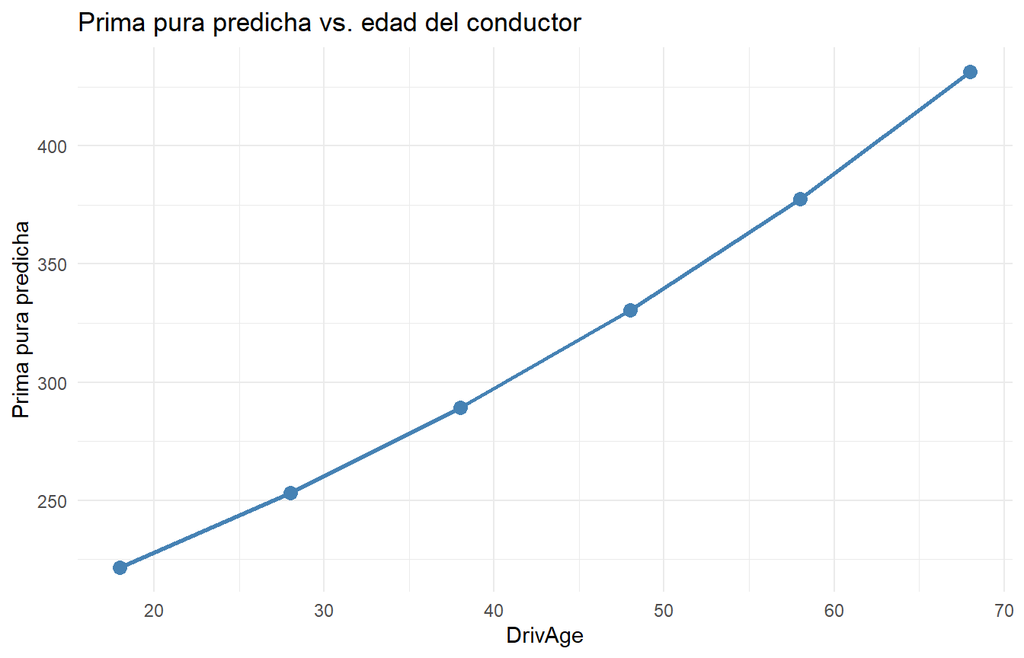

```r
ggplot(partial_table, aes(x = DrivAge, y = PredictedPurePremium)) +
  geom_line(color = "steelblue", linewidth = 1) +
  geom_point(size = 3, color = "steelblue") +
  labs(title = "Prima pura predicha vs. edad del conductor",
       x = "DrivAge", y = "Prima pura predicha") +
  theme_minimal()
```